# Law of Large Numbers

By intuition, more observations are better; if more observations are collected from the population (more data), samples of the data will be more representative of the general population.

#### Statistics and Probability

The theorem - the law of large numbers

- supports this intuition
- is a pillar of both of these ﬁelds and has important implications in applied machine learning.
- suggests the average result from repeating an experiment multiple times will better approximate the true or expected underlying result.

#### Applied Machine Learning

This law is critical for understanding and implementing

- The selection of training datasets
- Test datasets
- The evaluation of model skill in machine learning.

Profitable casinos exist because of the law of large numbers, they always make money in the long run.

#### Trials / Experiments

All sample observations for an experiment are drawn from an idealized population of observations.

- Observation: Result from one trial of an experiment.
- Sample: Group of results gathered from standalone/independent repetition of trials, giving multiple observations.
- Population: Space of all possible observations that could be seen from a trial.

#### The discipline of statistics, says that:

- As size of the sample increases, mean value of the sample will better approximate the mean or other expected value in the population.
- As the sample size goes to inﬁnity, the sample mean will converge to the population mean.

#### The discipline of probability theory, say that:

- With the law of large numbers, the mean of a large sample is close to the mean of the distribution.

### Demonstration in Python to show the decrease in error from the increase in sample size.

Design an idealized underlying distribution

- Using a Gaussian distribution with a mean of 50 and a standard deviation of 5.
- The expected value or mean of this population is 50.

```python
import pandas as pd
from numpy       import arange
import matplotlib.pyplot as plt
from scipy.stats import norm
```

### idealized population distribution

```python
# x-axis for the plot
xaxis = arange(30, 70, 1)
print("x-axis")
print(xaxis)
print(" ")

# y-axis for the plot
#
mean               = 50
standard_deviation = 5

yaxis = norm.pdf(xaxis, mean, standard_deviation)   # Probability density function at x
print("y-axis")
print(yaxis)
```

```
x-axis
[30 31 32 33 34 35 36 37 38 39 40 41 42 43 44 45 46 47 48 49 50 51 52 53
 54 55 56 57 58 59 60 61 62 63 64 65 66 67 68 69]

y-axis
[2.67660452e-05 5.83893852e-05 1.22380386e-04 2.46443834e-04
 4.76817640e-04 8.86369682e-04 1.58309032e-03 2.71659385e-03
 4.47890606e-03 7.09491857e-03 1.07981933e-02 1.57900317e-02
 2.21841669e-02 2.99454931e-02 3.88372110e-02 4.83941449e-02
 5.79383106e-02 6.66449206e-02 7.36540281e-02 7.82085388e-02
 7.97884561e-02 7.82085388e-02 7.36540281e-02 6.66449206e-02
 5.79383106e-02 4.83941449e-02 3.88372110e-02 2.99454931e-02
 2.21841669e-02 1.57900317e-02 1.07981933e-02 7.09491857e-03
 4.47890606e-03 2.71659385e-03 1.58309032e-03 8.86369682e-04
 4.76817640e-04 2.46443834e-04 1.22380386e-04 5.83893852e-05]
```

```python
sd1 = mean - standard_deviation
sd2 = mean + standard_deviation
```

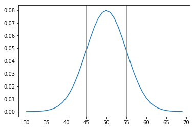

```python
# plot ideal population
plt.plot(xaxis, yaxis)

plt.axvline(x=sd1,ymin=0.00,ymax=1,color='grey')
plt.axvline(x=sd2,ymin=0.00,ymax=1,color='grey')

plt.show()
```

#### created is a plot of the designed population with the familiar bell shape, also showing 1 standard deviation each direction from the mean.

## -------------------------------------------------------------------------------

### Sampling: drawing independent random samples from the population

Forgetting everything known about the population.

- Create samples of diﬀerent sizes and calculate the mean.

Given intuition and the law of large numbers

- It is expected that as the size of the sample is increased, the sample mean will better approximate the population mean.

The example below calculates samples of diﬀerent sizes, estimates the mean and plots the errors in the mean from the expected mean (50).

```python
# demonstrate the law of large numbers
from numpy.random import seed
from numpy.random import randn
from numpy        import mean
from numpy        import array
```

```python
# seed the random number generator
seed(1)
```

```python
# draw 100 sample sizes

# sample sizes
sizes = list()  # create empty list go hold the sizes of the samples

for x in range (10, 20000, 200):  # draw sample sizes by steping thru range 200 at a time
    sizes.append(x)
print(len(sizes))
print(" ")
print(sizes)
```

```
100

[10, 210, 410, 610, 810, 1010, 1210, 1410, 1610, 1810, 2010, 2210, 2410, 2610, 2810, 3010, 3210, 3410, 3610, 3810, 4010, 4210, 4410, 4610, 4810, 5010, 5210, 5410, 5610, 5810, 6010, 6210, 6410, 6610, 6810, 7010, 7210, 7410, 7610, 7810, 8010, 8210, 8410, 8610, 8810, 9010, 9210, 9410, 9610, 9810, 10010…
```

```python
# generate samples of different sizes and calculate their means
means = [mean(5 * randn(size) + 50) for size in sizes]
print(len(means))
print(means)
```

```
100
[49.5142955459695, 50.465491303612566, 50.20439493481725, 50.06639075903241, 50.09226651425639, 50.02960760563608, 50.015346627662595, 50.15474522106567, 49.760289089674394, 50.11974338654227, 50.130186248291515, 49.93430858351253, 50.16422477028292, 50.002900504921556, 49.894048398712194, 50.088699…
```

```python
samples_df = pd.DataFrame(sizes,columns=["Sample Size"])
samples_df.index = pd.Index(i for i in range(1,101,1))
samples_df['mean'] = means
display(samples_df.head(8))
display(samples_df.tail(8))
```

|  | Sample Size | mean |
| --- | --- | --- |
| 1 | 10 | 49.514296 |
| 2 | 210 | 50.465491 |
| 3 | 410 | 50.204395 |
| 4 | 610 | 50.066391 |
| 5 | 810 | 50.092267 |
| 6 | 1010 | 50.029608 |
| 7 | 1210 | 50.015347 |
| 8 | 1410 | 50.154745 |

|  | Sample Size | mean |
| --- | --- | --- |
| 93 | 18410 | 49.948740 |
| 94 | 18610 | 49.997907 |
| 95 | 18810 | 49.929716 |
| 96 | 19010 | 49.987061 |
| 97 | 19210 | 49.951361 |
| 98 | 19410 | 50.004024 |
| 99 | 19610 | 50.035649 |
| 100 | 19810 | 50.034491 |

#### As size of the sample increases, mean value of the sample will better approximate the mean or other expected value in the population.

- Create plot comparing the size of the sample to the error of the sample mean from the population mean.
- Generally, the larger sample sizes have less error, can expect trend to continue, on average.
- Some sample means overestimate and some underestimate.
- Don't fall into the trap of assuming that the underestimate will fall on one side or another.

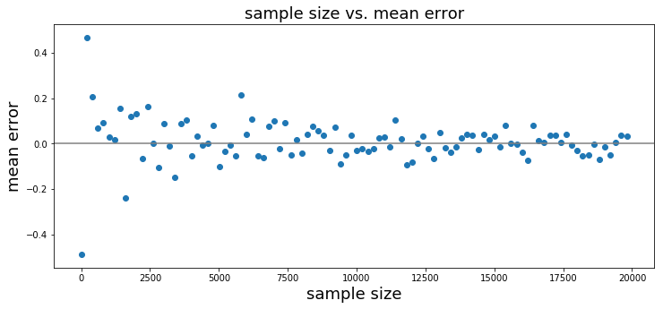

```python
# plot sample mean error vs sample size

plt.figure(figsize=(12,5))
plt.title("sample size vs. mean error", fontsize=18)
plt.xlabel("sample size", fontsize=18)
plt.ylabel("mean error",  fontsize=18)
plt.scatter(sizes, array(means)-50)  # calculates mean error
plt.axhline(y=0,xmin=0.00,xmax=20000,color='grey')
plt.show()
```

## ----------------------------------------------------------------------------------------

## Example of: Law of Large Numbers (real world dataset sampling)

```python
population = pd.read_csv("population.csv",
                         usecols=['FullName','Race','Gender','Age','Height','Weight','State'] )

population.index = pd.Index(i for i in range(1,5001,1))
display(population.shape)
display(population.head(10))
display(population.tail(10))

# eof variable is used in selection processes as the 'stop' point in a range.
# Must be number of rows + 1 because the eof is not included in the range.
# This ensures the last row is included in the range.

eof = population.shape[0] + 1
```

```
(5000, 7)
```

|  | Age | FullName | Gender | Height | Race | State | Weight |
| --- | --- | --- | --- | --- | --- | --- | --- |
| 1 | 18 | Payton C. Cole | M | 64.45 | W | GA | 201 |
| 2 | 66 | Andres J. Brown | M | 68.00 | W | NY | 161 |
| 3 | 41 | Wayne C. Robinson | M | 73.41 | W | CA | 177 |
| 4 | 41 | Jamie N. Johnson | F | 58.89 | W | NY | 181 |
| 5 | 66 | Jordan H. Fields | F | 65.11 | B | RI | 144 |
| 6 | 69 | Nathan J. Rogers | M | 69.16 | W | DE | 152 |
| 7 | 18 | Kathryn M. Nichols | F | 60.49 | W | PA | 165 |
| 8 | 62 | Kevin F. Jones | M | 71.43 | W | MS | 211 |
| 9 | 71 | Alexia L. Hill | F | 63.45 | W | WI | 112 |
| 10 | 57 | Fay N. Harris | F | 67.65 | W | NY | 127 |

|  | Age | FullName | Gender | Height | Race | State | Weight |
| --- | --- | --- | --- | --- | --- | --- | --- |
| 4991 | 62 | Michele I. Wood | F | 60.93 | W | OH | 142 |
| 4992 | 31 | Elmer D. Cook | M | 73.98 | W | TX | 180 |
| 4993 | 34 | Janice J. Carter | F | 67.35 | W | DE | 175 |
| 4994 | 47 | Jeanne N. Johnson | F | 60.94 | W | CO | 146 |
| 4995 | 34 | Vicki R. Jordan | F | 66.00 | W | TX | 192 |
| 4996 | 65 | Sharise H. Franklin | F | 60.47 | B | NC | 155 |
| 4997 | 31 | Chante C. Gray | M | 78.59 | B | RI | 166 |
| 4998 | 72 | Nancy A. Stewart | F | 60.11 | W | FL | 131 |
| 4999 | 20 | Sarah E. Phillips | F | 60.31 | W | NE | 192 |
| 5000 | 63 | Willie F. Henry | M | 67.99 | B | PA | 159 |

#### Population: Space of all possible observations that could be seen from a trial.

```python
pop_height_mean = population.Height.mean()
print(pop_height_mean)
```

```
66.52589400000002
```

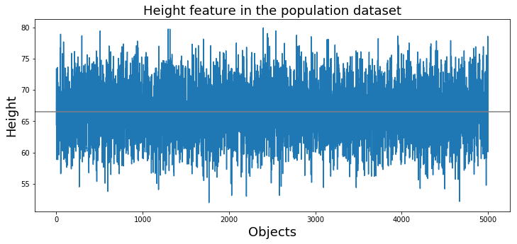

```python
plt.figure(figsize=(12,5))
population.Height.plot()
plt.title("Height feature in the population dataset", fontsize=18)
plt.xlabel("Objects", fontsize=18)
plt.ylabel("Height",  fontsize=18)
plt.axhline(y=pop_height_mean,xmin=0.00,xmax=20000,color='grey')
plt.show()
```

### Distribution of the (Height) feature in the population dataset is a gaussian-like normal distribution

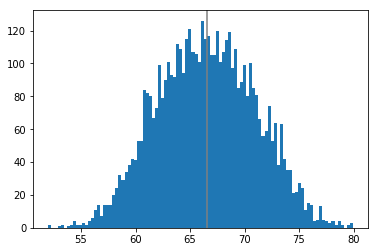

```python
plt.hist(population['Height'],bins=100)
plt.axvline(x=pop_height_mean,ymin=0.00,ymax=120,color='grey')
plt.show()
```

```python
# perform (499 trials) with progressively larger sample sizes

# sample sizes
sizes = list()  # create empty list go hold the sizes of the 499 trials

for x in range (10, len(population), 10):  # draw sample sizes by steping thru population object count 10 at a time
    sizes.append(x)

print("Sample sizes of the " + str(len(sizes))+" trials to be drawn from the population. \n")
print(sizes)
```

```
Sample sizes of the 499 trials to be drawn from the population.

[10, 20, 30, 40, 50, 60, 70, 80, 90, 100, 110, 120, 130, 140, 150, 160, 170, 180, 190, 200, 210, 220, 230, 240, 250, 260, 270, 280, 290, 300, 310, 320, 330, 340, 350, 360, 370, 380, 390, 400, 410, 420, 430, 440, 450, 460, 470, 480, 490, 500, 510, 520, 530, 540, 550, 560, 570, 580, 590, 600, 610, 620…
```

### Perform the 499 trials - accumulating mean height for each trial.

```python
from random import randrange

list_of_means = [ ]

for trial_sample_size in sizes:  # iterate the 499 trials

    # random process to select a list of objects from the population for the given sample size of that trial
    # uses the row index number to select the random objects from the available population.
    record_tags = []
    for index in range (0,trial_sample_size):
        record_tags.append(randrange(1,eof))

    # pull the objects into the trial for the randomly generated list of population objects.
    sample = population.loc[record_tags]

    # calculate the mean of the Height feature for all objects in the sample.
    # append the samples calculate mean to the list_of_means
    list_of_means.append(sample.Height.mean())

print("Mean of Height, for each of the 499 trials: \n")
print(list_of_means)
```

```
Mean of Height, for each of the 499 trials:

[66.232, 64.9255, 68.158, 65.33500000000001, 66.92060000000001, 67.59933333333333, 65.9027142857143, 66.95125000000003, 66.17111111111112, 66.263, 65.9048181818182, 66.52091666666668, 66.99130769230767, 66.756, 65.70173333333332, 66.336875, 67.16594117647061, 66.66933333333334, 65.97521052631579, 66…
```

#### Observation: Result from one trial of an experiment.

- Each entry in the above means list is one(1) observation in the experiment.

```python
# load trial sample size and its Height feature mean into a DataFrame
samples2_df = pd.DataFrame(sizes,columns=["Trial Sample Size"])
samples2_df.index = pd.Index(i for i in range(1,len(sizes)+1,1))
samples2_df['Height mean observation'] = list_of_means
display(samples2_df.head(8))
display(samples2_df.tail(8))
```

|  | Trial Sample Size | Height mean observation |
| --- | --- | --- |
| 1 | 10 | 66.232000 |
| 2 | 20 | 64.925500 |
| 3 | 30 | 68.158000 |
| 4 | 40 | 65.335000 |
| 5 | 50 | 66.920600 |
| 6 | 60 | 67.599333 |
| 7 | 70 | 65.902714 |
| 8 | 80 | 66.951250 |

|  | Trial Sample Size | Height mean observation |
| --- | --- | --- |
| 492 | 4920 | 66.489283 |
| 493 | 4930 | 66.531428 |
| 494 | 4940 | 66.590008 |
| 495 | 4950 | 66.577046 |
| 496 | 4960 | 66.423442 |
| 497 | 4970 | 66.506002 |
| 498 | 4980 | 66.459279 |
| 499 | 4990 | 66.531479 |

```
Total objects in population: 5000

Mean of weight in total population: 66.52589400000002
```

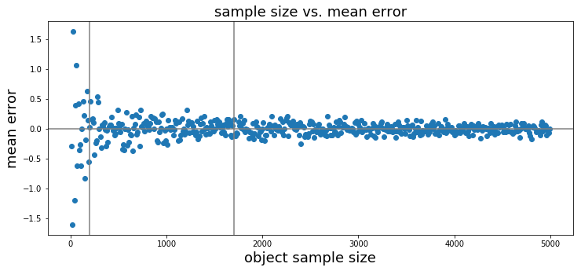

```python
# plot sample mean error vs sample size

print("Total objects in population: " + str(len(population)) + "\n")
print("Mean of weight in total population: " + str(pop_height_mean) + "\n")

plt.figure(figsize=(12,5))
plt.title("sample size vs. mean error", fontsize=18)
plt.xlabel("object sample size", fontsize=18)
plt.ylabel("mean error",  fontsize=18)
plt.scatter(sizes, array(list_of_means) - pop_height_mean)  # calculates mean error
plt.axhline(y=0,xmin=0.00,xmax=20000,color='grey')
plt.axvline(x=200, ymin=-3.00, ymax=2,color='grey')
plt.axvline(x=1700, ymin=-3.00, ymax=2,color='grey')
plt.show()
```

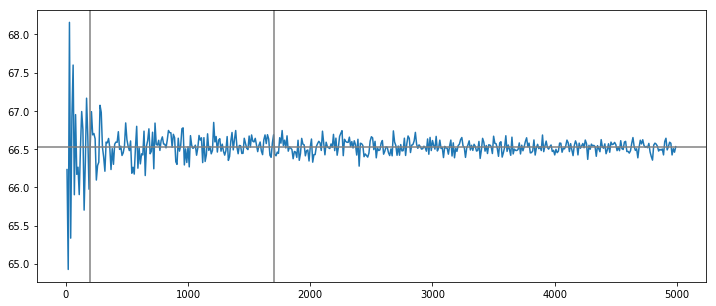

```python
# plot ideal population
plt.figure(figsize=(12,5))
plt.plot(samples2_df['Trial Sample Size'], samples2_df['Height mean observation'])
plt.axhline(y=pop_height_mean,xmin=0.00,xmax=20000,color='grey')
plt.axvline(x=200, ymin=-3.00, ymax=2,color='grey')
plt.axvline(x=1700, ymin=-3.00, ymax=2,color='grey')
plt.show()
```

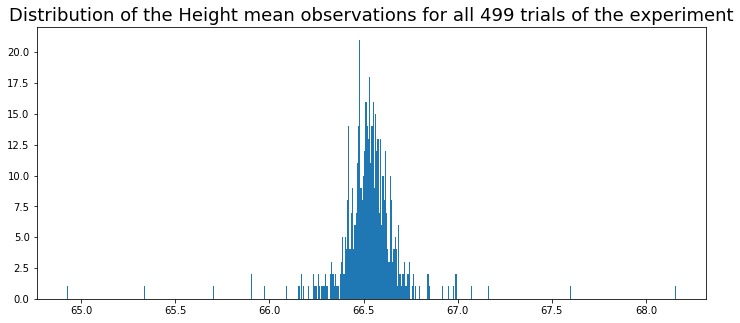

```python
#
plt.figure(figsize=(12,5))
plt.title("Distribution of the Height mean observations for all 499 trials of the experiment", fontsize=18)
plt.hist(samples2_df['Height mean observation'],bins=500)
# show line plot
plt.show()
```